# Homework 6

Shiyu Zhang

## Tree-Based Models

For this assignment, we will continue working with the file `"pokemon.csv"`, found in `/data`. The file is from Kaggle: https://www.kaggle.com/abcsds/pokemon.

The [Pokémon](https://www.pokemon.com/us/) franchise encompasses video games, TV shows, movies, books, and a card game. This data set was drawn from the video game series and contains statistics about 721 Pokémon, or “pocket monsters.” In Pokémon games, the user plays as a trainer who collects, trades, and battles Pokémon to (a) collect all the Pokémon and (b) become the champion Pokémon trainer.

Each Pokémon has a [primary type](https://bulbapedia.bulbagarden.net/wiki/Type) (some even have secondary types). Based on their type, a Pokémon is strong against some types, and vulnerable to others. (Think rock, paper, scissors.) A Fire-type Pokémon, for example, is vulnerable to Water-type Pokémon, but strong against Grass-type.

The goal of this assignment is to build a statistical learning model that can predict the **primary type** of a Pokémon based on its generation, legendary status, and six battle statistics.

**Note: Fitting ensemble tree-based models can take a little while to run. Consider running your models outside of the .Rmd, storing the results, and loading them in your .Rmd to minimize time to knit.**

### Exercise 1

Read in the data and set things up as in Homework 5:

- Use `clean_names()`
- Filter out the rarer Pokémon types
- Convert `type_1` and `legendary` to factors

Do an initial split of the data; you can choose the percentage for splitting. Stratify on the outcome variable.

Fold the training set using *v*-fold cross-validation, with `v = 5`. Stratify on the outcome variable.

Set up a recipe to predict `type_1` with `legendary`, `generation`, `sp_atk`, `attack`, `speed`, `defense`, `hp`, and `sp_def`:

- Dummy-code `legendary` and `generation`;
- Center and scale all predictors.

```r
library(tidyverse)
library(tidymodels)
library(corrplot)
library(rpart.plot)
library(vip)
library(janitor)
library(randomForest)
library(xgboost)
library(ranger)
tidymodels_prefer()
```

```r
setwd("C:/Users/DELL/Desktop/1126hw6_131")
pokemon <- read.csv("Pokemon.csv")
pokemon_cleannames <- clean_names(pokemon)
colnames(pokemon)
```

```
##  [1] "X."         "Name"       "Type.1"     "Type.2"     "Total"
##  [6] "HP"         "Attack"     "Defense"    "Sp..Atk"    "Sp..Def"
## [11] "Speed"      "Generation" "Legendary"
```

```r
colnames(pokemon_cleannames)
```

```
##  [1] "x"          "name"       "type_1"     "type_2"     "total"
##  [6] "hp"         "attack"     "defense"    "sp_atk"     "sp_def"
## [11] "speed"      "generation" "legendary"
```

```r
pokemon_filter <- pokemon_cleannames %>%
  filter(type_1 == c("Bug", "Fire", "Grass", "Normal", "Water", "Psychic"))
pokemon1<-pokemon_filter%>%
  mutate(type_1=factor(type_1),
         legendary=factor(legendary))

set.seed(1234)
split_pokemon <- initial_split(pokemon1, prop = 0.70,strata = type_1)
train <- training(split_pokemon)
test <- testing(split_pokemon)

train_folds <- vfold_cv(train, v = 5, strata = type_1)

recipe <- train %>%
  recipe(type_1 ~ legendary + generation + sp_atk + attack+ speed + defense + hp + sp_def) %>%
  step_dummy(legendary)%>%
  step_dummy(generation)%>%
  step_center(all_predictors())%>%
  step_scale(all_predictors())

recipe
```

```
## Recipe
##
## Inputs:
##
##       role #variables
##    outcome          1
##  predictor          8
##
## Operations:
##
## Dummy variables from legendary
## Dummy variables from generation
## Centering for all_predictors()
## Scaling for all_predictors()
```

### Exercise 2

Create a correlation matrix of the training set, using the `corrplot` package. *Note: You can choose how to handle the continuous variables for this plot; justify your decision(s).*

What relationships, if any, do you notice? Do these relationships make sense to you?

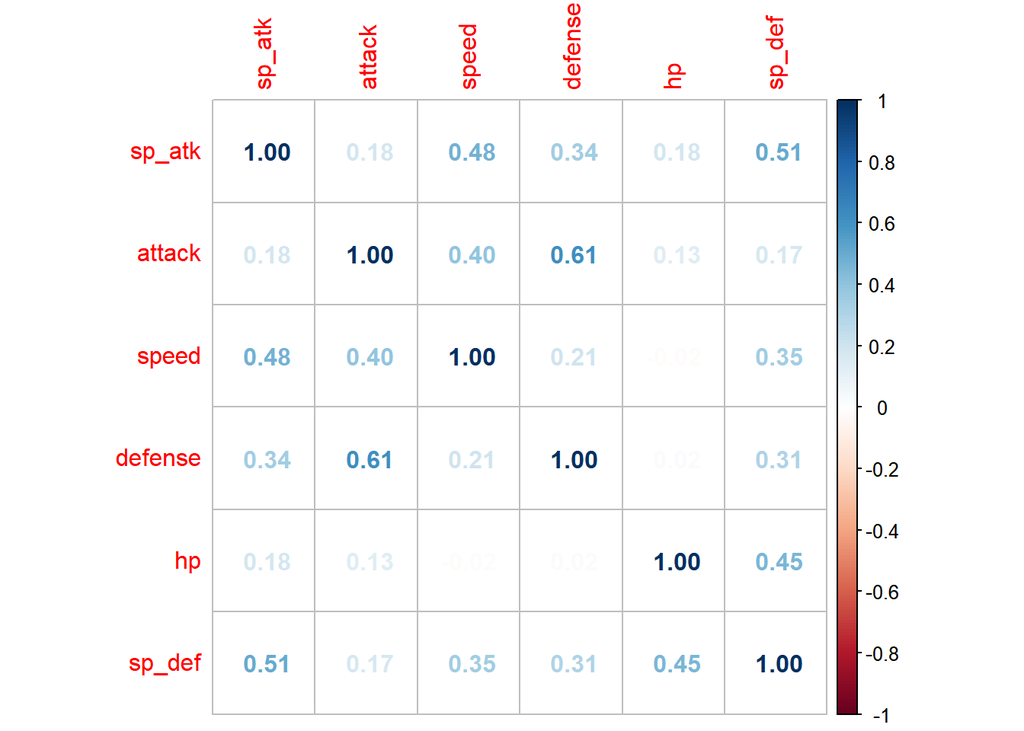

```r
corr<- train %>%
  select(c(sp_atk, attack, speed, defense, hp, sp_def)) %>%
  cor()

corrplot(corr, method = "number")
```

Answer: We only select numerical independent variables and draw the correlation coefficient matrix. We find that there is a certain degree of positive correlation between variables, and the correlation coefficient of attack and defense is the highest, reaching 0.61.

### Exercise 3

First, set up a decision tree model and workflow. Tune the `cost_complexity` hyperparameter. Use the same levels we used in Lab 7 – that is, `range = c(-3, -1)`. Specify that the metric we want to optimize is `roc_auc`.

Print an `autoplot()` of the results. What do you observe? Does a single decision tree perform better with a smaller or larger complexity penalty?

```r
model_tree<- decision_tree() %>%
  set_engine("rpart") %>%
  set_mode("classification") %>%
  set_args(cost_complexity = tune())

workflow_tree <- workflow() %>%
  add_model(model_tree) %>%
  add_recipe(recipe)

tree_grid <- grid_regular(cost_complexity(range = c(-3, -1)), levels = 10)
```

```r
tree_tune_res <- tune_grid(
  workflow_tree,
  resamples = train_folds,
  grid = tree_grid,
  metrics = metric_set(roc_auc)
  )
```

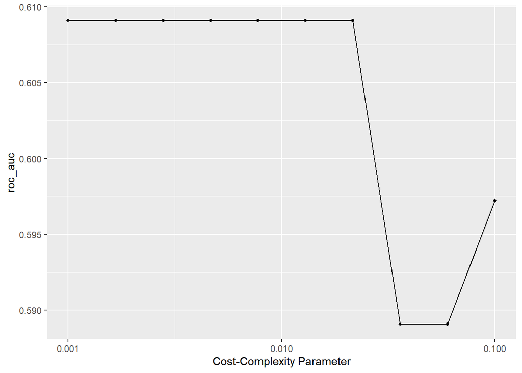

```r
#save(tree_tune_res,file = "C:/Users/DELL/Desktop/1126hw6_131/tree_tune_res.rda")
load("C:/Users/DELL/Desktop/1126hw6_131/tree_tune_res.rda")
autoplot(tree_tune_res)
```

Answer: We find that as the parameter cost_complexity increases, the AUC value of the model instead decreases. That means a single decision tree performs better with a smaller complexity penalty.

### Exercise 4

What is the `roc_auc` of your best-performing pruned decision tree on the folds? *Hint: Use `collect_metrics()` and `arrange()`.*

```r
collect_metrics(tree_tune_res) %>%
  arrange(-mean)
```

```
## # A tibble: 10 x 7
##    cost_complexity .metric .estimator  mean     n std_err .config
##              <dbl> <chr>   <chr>      <dbl> <int>   <dbl> <chr>
##  1         0.001   roc_auc hand_till  0.609     5  0.0503 Preprocessor1_Model01
##  2         0.00167 roc_auc hand_till  0.609     5  0.0503 Preprocessor1_Model02
##  3         0.00278 roc_auc hand_till  0.609     5  0.0503 Preprocessor1_Model03
##  4         0.00464 roc_auc hand_till  0.609     5  0.0503 Preprocessor1_Model04
##  5         0.00774 roc_auc hand_till  0.609     5  0.0503 Preprocessor1_Model05
##  6         0.0129  roc_auc hand_till  0.609     5  0.0503 Preprocessor1_Model06
##  7         0.0215  roc_auc hand_till  0.609     5  0.0503 Preprocessor1_Model07
##  8         0.1     roc_auc hand_till  0.597     5  0.0288 Preprocessor1_Model10
##  9         0.0359  roc_auc hand_till  0.589     5  0.0368 Preprocessor1_Model08
## 10         0.0599  roc_auc hand_till  0.589     5  0.0368 Preprocessor1_Model09
```

Answer: The roc_auc of best-performing pruned decision tree on the folds is 0.6090741.

### Exercise 5

Using `rpart.plot`, fit and visualize your best-performing pruned decision tree with the *training* set.

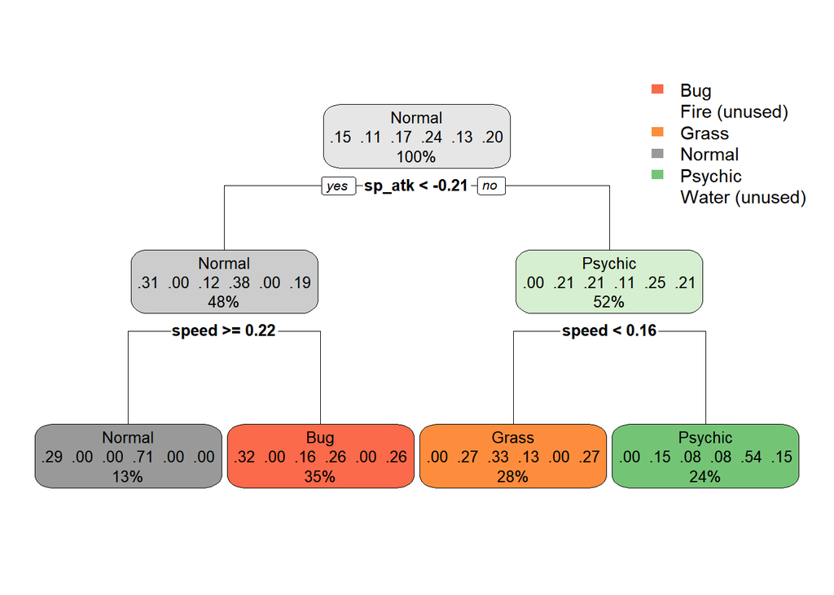

```r
best_param <- select_best(tree_tune_res, metric = "roc_auc")

tree_final <- finalize_workflow(workflow_tree, best_param)

tree_final_fit <- fit(tree_final, data = train)

tree_final_fit %>%
  extract_fit_engine() %>%
  rpart.plot()
```

### Exercise 5

Now set up a random forest model and workflow. Use the `ranger` engine and set `importance = "impurity"`. Tune `mtry`, `trees`, and `min_n`. Using the documentation for `rand_forest()`, explain in your own words what each of these hyperparameters represent.

Create a regular grid with 8 levels each. You can choose plausible ranges for each hyperparameter. Note that `mtry` should not be smaller than 1 or larger than 8. **Explain why not. What type of model would `mtry = 8` represent?**

```r
model_rf <- rand_forest() %>%
  set_engine("ranger", importance = "impurity") %>%
  set_mode("classification") %>%
  set_args(mtry = tune(), trees = tune(), min_n = tune())

workflow_rf <- workflow() %>%
  add_model(model_rf ) %>%
  add_recipe(recipe)

rf_grid <- grid_regular(mtry(range = c(1, 8)), trees(range = c(1, 8)),
                        min_n(range = c(1, 8)), levels = 8)
```

Answer:  
mtry: represents how many independent variables are randomly selected from all independent variables for each decision tree.  
trees: the number of decision trees in the random forest model.  
min_n: The condition that restricts the continued division of subtree. If the number of samples of a node is less than this value, the division will not continue.

There are only 8 predictors in the model,so mtry should not be smaller than 1 or larger than 8. When mtry is 8 means we use all the predictors for each decision tree.

### Exercise 6

Specify `roc_auc` as a metric. Tune the model and print an `autoplot()` of the results. What do you observe? What values of the hyperparameters seem to yield the best performance?

```r
rf_tune_res <- tune_grid(
  workflow_rf,
  resamples = train_folds,
  grid = rf_grid,
  metrics = metric_set(roc_auc)
)
```

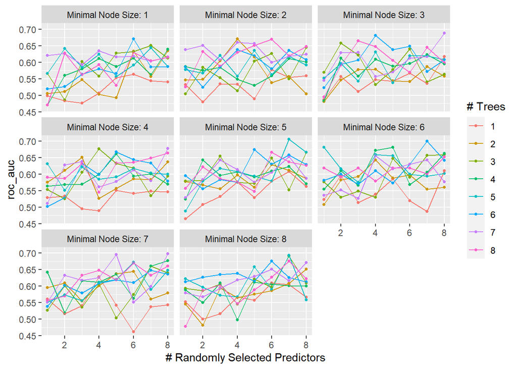

```r
#save(rf_tune_res,file = "C:/Users/DELL/Desktop/1126hw6_131/rf_tune_res.rda")
load("C:/Users/DELL/Desktop/1126hw6_131/rf_tune_res.rda")
autoplot(rf_tune_res)
```

### Exercise 7

What is the `roc_auc` of your best-performing random forest model on the folds? *Hint: Use `collect_metrics()` and `arrange()`.*

```r
collect_metrics(rf_tune_res) %>%
  arrange(-mean)
```

```
## # A tibble: 512 x 9
##     mtry trees min_n .metric .estimator  mean     n std_err .config
##    <int> <int> <int> <chr>   <chr>      <dbl> <int>   <dbl> <chr>
##  1     7     5     5 roc_auc hand_till  0.705     5  0.0351 Preprocessor1_Model~
##  2     7     6     6 roc_auc hand_till  0.700     5  0.0114 Preprocessor1_Model~
##  3     8     7     7 roc_auc hand_till  0.698     5  0.0483 Preprocessor1_Model~
##  4     5     7     7 roc_auc hand_till  0.696     5  0.0392 Preprocessor1_Model~
##  5     7     5     8 roc_auc hand_till  0.693     5  0.0507 Preprocessor1_Model~
##  6     7     3     8 roc_auc hand_till  0.691     5  0.0521 Preprocessor1_Model~
##  7     8     7     3 roc_auc hand_till  0.688     5  0.0357 Preprocessor1_Model~
##  8     5     4     6 roc_auc hand_till  0.681     5  0.0198 Preprocessor1_Model~
##  9     1     5     6 roc_auc hand_till  0.681     5  0.0361 Preprocessor1_Model~
## 10     4     6     3 roc_auc hand_till  0.681     5  0.0385 Preprocessor1_Model~
## # ... with 502 more rows
```

### Exercise 8

Create a variable importance plot, using `vip()`, with your best-performing random forest model fit on the *training* set.

Which variables were most useful? Which were least useful? Are these results what you expected, or not?

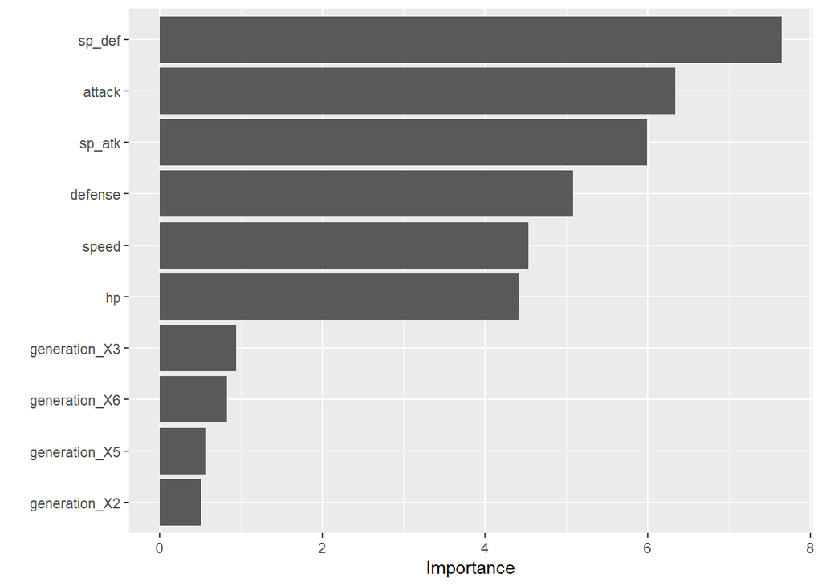

```r
set.seed(1234)
best_rf <- select_best(rf_tune_res, metric = "roc_auc")

rf_final <- finalize_workflow(workflow_rf, best_rf)

rf_final_fit <- fit(rf_final, data = train)

rf_final_fit %>%
  pull_workflow_fit() %>%
  vip()
```

### Exercise 9

Finally, set up a boosted tree model and workflow. Use the `xgboost` engine. Tune `trees`. Create a regular grid with 10 levels; let `trees` range from 10 to 2000. Specify `roc_auc` and again print an `autoplot()` of the results.

What do you observe?

What is the `roc_auc` of your best-performing boosted tree model on the folds? *Hint: Use `collect_metrics()` and `arrange()`.*

```r
model_boost <- boost_tree() %>%
  set_engine("xgboost") %>%
  set_mode("classification") %>%
  set_args(trees = tune())

workflow_boost <- workflow() %>%
  add_model(model_boost ) %>%
  add_recipe(recipe)

boost_grid <- grid_regular(trees(range = c(10, 2000)), levels = 10)
```

```r
boost_tune_res <- tune_grid(
  workflow_boost,
  resamples = train_folds,
  grid = boost_grid,
  metrics = metric_set(roc_auc)
  )
```

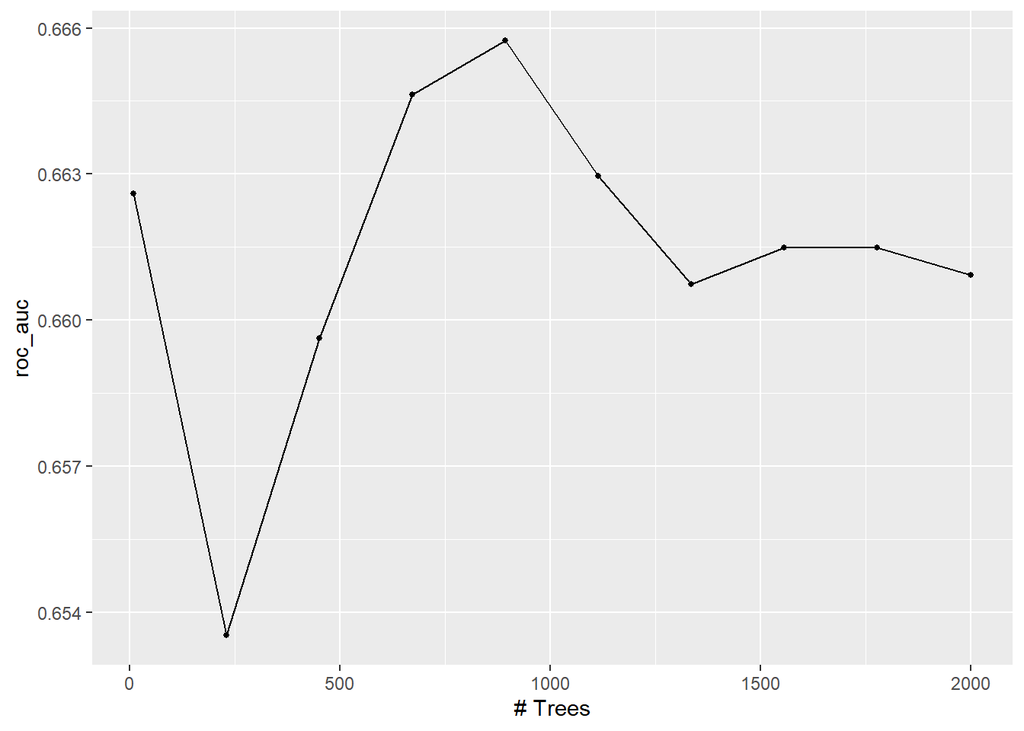

```r
#save(boost_tune_res,file = "C:/Users/DELL/Desktop/1126hw6_131/boost_tune_res.rda")
load("C:/Users/DELL/Desktop/1126hw6_131/boost_tune_res.rda")

autoplot(boost_tune_res)
```

```r
collect_metrics(boost_tune_res) %>%
  arrange(-mean)
```

```
## # A tibble: 10 x 7
##    trees .metric .estimator  mean     n std_err .config
##    <int> <chr>   <chr>      <dbl> <int>   <dbl> <chr>
##  1   894 roc_auc hand_till  0.666     5  0.0506 Preprocessor1_Model05
##  2   673 roc_auc hand_till  0.665     5  0.0515 Preprocessor1_Model04
##  3  1115 roc_auc hand_till  0.663     5  0.0511 Preprocessor1_Model06
##  4    10 roc_auc hand_till  0.663     5  0.0516 Preprocessor1_Model01
##  5  1557 roc_auc hand_till  0.661     5  0.0492 Preprocessor1_Model08
##  6  1778 roc_auc hand_till  0.661     5  0.0492 Preprocessor1_Model09
##  7  2000 roc_auc hand_till  0.661     5  0.0500 Preprocessor1_Model10
##  8  1336 roc_auc hand_till  0.661     5  0.0491 Preprocessor1_Model07
##  9   452 roc_auc hand_till  0.660     5  0.0536 Preprocessor1_Model03
## 10   231 roc_auc hand_till  0.654     5  0.0557 Preprocessor1_Model02
```

Answer: From the above figure, we can see that with the increase of the number of trees, the AUC value first decreases greatly, then increases, and finally decreases gradually. The roc_auc of the best-performing boosted tree model on the folds is 0.6657407.